# CMSC320 Final Project - An Analysis of the Correlation Between COVID-19 Data and State Political Affiliations

By: Ben Hardison (CMSC320 Summer I 2021)

# Introduction

As the COVID-19 pandemic winds down and more people become fully-vaccinated, we reflect on the loss of countless human lives, as well as the collective grief of a nation mourning their loved ones. At the same time, our lives are slowly returning to the way they were before, as businesses, schools, and public gathering places re-open and remove the pandemic precautions we have become so used to following.

It is no secret that the United States was one of countries with the highest number of COVID infections and deaths, and as we move into the future, health officials are asking themselves one glaring question…

> *“What went wrong, and how can we better prepare for pandemics like this in the future?”*

It is not an easy question to answer, and it is one that will be discussed, debated, and researched for years to come. Today, I want to lend my voice to that cause, and I will do so by shifting my perspective to one area. Politics.

The way the Trump administration handled the pandemic is a topic of much scrutiny, and rightly so. In the wake of a deadly virus outbreak, the people in charge should be held accountable for action (and inaction) taken on the government level to prevent the spread of the virus and save lives. However, this administrations response is notable in the way that it politicized an issue that for the greater good of the public probably should not have been politicized. From doubting the virus’s existence in the early days of the outbreak, to consistently undermining the effectiveness of the precautions in place, an argument could be made that the actions of the Trump administration actively encouraged followers to reject the guidance of health officials and carry on as if nothing were happening.

The question I want to ask is this. Is there is a connection between political affiliation and COVID outbreaks in the US? For example, were there more COVID cases in states that leaned Republican compared to states that leaned Democratic? It is a worthwhile topic to explore, as uncovering political roots in the spread of virus cases could be beneficial in determining where to prioritize prevention efforts when another pandemic arises. By doing this, I can also shed light on the data science pipeline by walking you through a real-world example of data science at work.

> (Naturally, the politicization of any issue in government can be a hot topic, and the pandemic is no exception. I am choosing to investigate this interaction out of personal curiosity and to determine whether a connection exists, not to point a finger at one group or another.)

So, without further ado, let us begin with the first step in the data science pipeline: data collection.

# Data collection/curation

Any good data scientist begins his work by collecting the data he or she wants to work with. This can take a variety of forms, from collecting the data personally through surveys, to downloading data that has been previously collected from another source. For this research, we will be doing the latter. To explore the relationship between COVID cases and political affiliation, we will need to combine data from a variety of sources. Specifically, we will be accessing the data from four separate sources and combining it into a data set we can work with. Those sources are...

> - **United States COVID-19 Cases and Deaths by State over Time**

>   > [https://data.cdc.gov/Case-Surveillance/United-States-COVID-19-Cases-and-Deaths-by-State-o/9mfq-cb36/data](http://url)  
>   > This data table from the CDC compiles up to the date COVID-19 reports from states and federal jurisdictions, including total cases, total deaths, and more starting on January 20th, 2020. With over 32,000 entries, this data set will be our primary source of COVID-19 data relating to total cases and deaths. Since the entries in our table are sorted by state, we should be able to easily match entries in this table with political data. Speaking of which...
> - **2020 National Popular Vote Tracker**

>   > [https://cookpolitical.com/2020-national-popular-vote-tracker](http://url)  
>   > From the Cook Political Report, this data set compiles data related to the 2020 presidential election, specifically the number of votes cast for Trump and Biden, as well as what political party each state was called for. With some tidying, we should be able to easily match this data with our COVID-19 data from the CDC.
> - **Annual Estimates of the Resident Population for the Nation and States**

>   > [https://www.census.gov/programs-surveys/popest/technical-documentation/research/evaluation-estimates/2020-evaluation-estimates/2010s-state-total.html](http://url)  
>   > When it comes to discussing COVID cases in individual states, it would probably be helpful to know the total population of each state. To do this, we download state population totals from the US Census Bureau. While these totals are estimates, they are as close as we will get to knowing how many people are in each state.
> - **COVID-19 Vaccinations in the United States**

>   > [https://covid.cdc.gov/covid-data-tracker/#vaccinations](http://url)  
>   > Now that COVID vaccinations are being distributed to the public, it could be helpful to know how many people are getting the vaccine, as well as the percent of the population of each state that is fully vaccinated. Again, we can easily get up to the date data on this subject from the CDC.

It is worth noting that when I started on this project, I was only using data from the first two data sets. After performing some analysis, I realized it would be helpful to have access to the population and vaccination data located in the other two tables. This is a common practice in data science. Before analyzing our data, we might not know what kind of connections and trends we want to explore, and later we might have to return to our data collection phase to explore some aspect of our data further. While the data science pipeline might seem straightforward, backtracking to previous steps is sometimes required.

Before we start to write any code, we must first import the Python libraries we want to use. If you are interested in learning more or are confused by any of the functions I use, I have provided links to documentation in the Sources section at the end of the notebook. After importing the data we want to use, we move on to the next step in the data science pipeline, data management.

```python
import math
import pandas as pd
import numpy as np
import matplotlib.pyplot as plt
from sklearn.neighbors import KNeighborsClassifier
from sklearn.tree import DecisionTreeClassifier
from sklearn.model_selection import cross_val_score
```

```python
# We import the CDC's COVID-19 data
cdc_data_raw = pd.read_csv('United_States_COVID-19_Cases_and_Deaths_by_State_over_Time.csv')
cdc_data_raw.head(5)
```

|  | submission_date | state | tot_cases | conf_cases | prob_cases | new_case | pnew_case | tot_death | conf_death | prob_death | new_death | pnew_death | created_at | consent_cases | consent_deaths |
| --- | --- | --- | --- | --- | --- | --- | --- | --- | --- | --- | --- | --- | --- | --- | --- |
| 0 | 03/11/2021 | KS | 297229 | 241035.0 | 56194.0 | 0 | 0.0 | 4851 | NaN | NaN | 0 | 0.0 | 03/12/2021 03:20:13 PM | Agree | NaN |
| 1 | 06/11/2021 | TX | 2965966 | NaN | NaN | 1463 | 355.0 | 51158 | NaN | NaN | 17 | 0.0 | 06/13/2021 12:00:00 AM | Not agree | Not agree |
| 2 | 02/04/2020 | AR | 0 | NaN | NaN | 0 | NaN | 0 | NaN | NaN | 0 | NaN | 03/26/2020 04:22:39 PM | Not agree | Not agree |
| 3 | 10/22/2020 | MP | 88 | 88.0 | 0.0 | 0 | 0.0 | 2 | 2.0 | 0.0 | 0 | 0.0 | 10/23/2020 01:44:31 PM | Agree | Agree |
| 4 | 08/12/2020 | AS | 0 | NaN | NaN | 0 | 0.0 | 0 | NaN | NaN | 0 | 0.0 | 08/13/2020 02:12:28 PM | NaN | NaN |

```python
# We import our 2020 presidential election data
election_data_raw = pd.read_csv('Popular vote backend - Sheet1.csv')
election_data_raw.head(10)
```

|  | state | called | final | dem_votes | rep_votes | other_votes | dem_percent | rep_percent | other_percent | dem_this_margin | ... | stateid | EV | X | Y | State_num | Center_X | Center_Y | Unnamed: 19 | 2016 Margin | Total 2016 Votes |
| --- | --- | --- | --- | --- | --- | --- | --- | --- | --- | --- | --- | --- | --- | --- | --- | --- | --- | --- | --- | --- | --- |
| 0 | U.S. Total | D | Yes | 81,282,916 | 74,223,369 | 2,891,441 | 51.3% | 46.9% | 1.8% | 4.5% | ... | NaN | NaN | NaN | NaN | NaN | NaN | NaN | NaN | 0.020995 | 136,639,848 |
| 1 | 15 Key Battlegrounds | NaN | NaN | 31,908,248 | 33,002,287 | 950,354 | 48.4% | 50.1% | 1.4% | -1.7% | ... | NaN | NaN | NaN | NaN | NaN | NaN | NaN | NaN | -0.036220 | 56,209,173 |
| 2 | Non-Battlegrounds | NaN | NaN | 49,374,668 | 41,221,082 | 1,941,087 | 53.4% | 44.5% | 2.1% | 8.8% | ... | NaN | NaN | NaN | NaN | NaN | NaN | NaN | NaN | 0.060978 | 80,430,331 |
| 3 | 15 Key Battlegrounds | NaN | NaN | NaN | NaN | NaN | NaN | NaN | NaN | NaN | ... | NaN | NaN | NaN | NaN | NaN | NaN | NaN | NaN | NaN | NaN |
| 4 | Arizona | D | Yes | 1,672,143 | 1,661,686 | 53,497 | 49.4% | 49.1% | 1.6% | 0.3% | ... | AZ | 11.0 | 2.0 | 2.0 | 4.0 | 205.0 | 374.0 | NaN | -0.035456 | 2,573,165 |
| 5 | Florida | R | Yes | 5,297,045 | 5,668,731 | 101,680 | 47.9% | 51.2% | 0.9% | -3.4% | ... | FL | 29.0 | 8.0 | 0.0 | 12.0 | 787.0 | 520.0 | NaN | -0.011986 | 9,420,039 |
| 6 | Georgia | D | Yes | 2,473,633 | 2,461,854 | 62,229 | 49.5% | 49.3% | 1.2% | 0.2% | ... | GA | 16.0 | 7.0 | 1.0 | 13.0 | 734.0 | 419.0 | NaN | -0.051313 | 4,092,373 |
| 7 | Iowa | R | Yes | 759,061 | 897,672 | 34,138 | 44.9% | 53.1% | 2.0% | -8.2% | ... | IA | 6.0 | 5.0 | 4.0 | 19.0 | 536.0 | 223.0 | NaN | -0.094068 | 1,566,031 |
| 8 | Maine 2nd District | R | Yes | 168,696 | 196,692 | 10,961 | 44.8% | 52.3% | 2.9% | -7.4% | ... | ME2 | 1.0 | 12.0 | 8.0 | 102.0 | 919.0 | 92.0 | NaN | -0.102882 | 353,416 |
| 9 | Michigan | D | Yes | 2,804,040 | 2,649,852 | 85,410 | 50.6% | 47.8% | 1.5% | 2.8% | ... | MI | 16.0 | 7.0 | 5.0 | 26.0 | 681.0 | 190.0 | NaN | -0.002230 | 4,799,284 |

10 rows × 22 columns

```python
# We import the Census Bureau's state population data
pop_data_raw = pd.read_excel('nst-est2020.xlsx', skiprows = 8, nrows = 51)
pop_data_raw.head(10)
```

|  | West | 71945553 | 71946912 | 72101630 | 72791588 | 73482530 | 74173435 | 74933166 | 75751299 | 76570256 | 77267367 | 77841481 | 78300384 | 78654756 |
| --- | --- | --- | --- | --- | --- | --- | --- | --- | --- | --- | --- | --- | --- | --- |
| 0 | .Alabama | 4779736 | 4780118 | 4785514 | 4799642 | 4816632 | 4831586 | 4843737 | 4854803 | 4866824 | 4877989 | 4891628 | 4907965 | 4921532 |
| 1 | .Alaska | 710231 | 710246 | 713982 | 722349 | 730810 | 737626 | 737075 | 738430 | 742575 | 740983 | 736624 | 733603 | 731158 |
| 2 | .Arizona | 6392017 | 6392292 | 6407342 | 6473416 | 6556344 | 6634690 | 6732873 | 6832810 | 6944767 | 7048088 | 7164228 | 7291843 | 7421401 |
| 3 | .Arkansas | 2915918 | 2916029 | 2921998 | 2941038 | 2952876 | 2960459 | 2968759 | 2979732 | 2991815 | 3003855 | 3012161 | 3020985 | 3030522 |
| 4 | .California | 37253956 | 37254522 | 37319550 | 37636311 | 37944551 | 38253768 | 38586706 | 38904296 | 39149186 | 39337785 | 39437463 | 39437610 | 39368078 |
| 5 | .Colorado | 5029196 | 5029319 | 5047539 | 5121900 | 5193660 | 5270774 | 5352637 | 5454328 | 5543844 | 5617421 | 5697155 | 5758486 | 5807719 |
| 6 | .Connecticut | 3574097 | 3574151 | 3579173 | 3588632 | 3595211 | 3595792 | 3595697 | 3588561 | 3579830 | 3575324 | 3574561 | 3566022 | 3557006 |
| 7 | .Delaware | 897934 | 897947 | 899647 | 907590 | 915518 | 924062 | 933131 | 942065 | 949989 | 957942 | 966985 | 976668 | 986809 |
| 8 | .District of Columbia | 601723 | 601767 | 605282 | 620290 | 635737 | 651559 | 663603 | 677014 | 687576 | 697079 | 704147 | 708253 | 712816 |
| 9 | .Florida | 18801310 | 18804589 | 18846143 | 19055607 | 19302016 | 19551678 | 19853880 | 20219111 | 20627237 | 20977089 | 21254926 | 21492056 | 21733312 |

```python
# We import the CDC's vaccine data
vaccine_data_raw = pd.read_csv('covid19_vaccinations_in_the_united_states.csv',skiprows = 2)
vaccine_data_raw.head(10)
```

|  | State/Territory/Federal Entity | Total Doses Delivered | Doses Delivered per 100K | 18+ Doses Delivered per 100K | Total Doses Administered by State where Administered | Doses Administered per 100k by State where Administered | 18+ Doses Administered by State where Administered | 18+ Doses Administered per 100K by State where Administered | People with at least One Dose by State of Residence | Percent of Total Pop with at least One Dose by State of Residence | ... | Percent of 12+ Pop with at least One Dose by State of Residence | People 12+ Fully Vaccinated by State of Residence | Percent of 12+ Pop Fully Vaccinated by State of Residence | People 12+ Fully Vaccinated_Moderna_Resident | People 12+ Fully Vaccinated_Pfizer_Resident | People 12+ Fully Vaccinated_Janssen_Resident | People 12+ Fully Vaccinated_Unknown 2-dose Manuf_Resident | 12+ Doses Administered by State where Administered | Doses Administered per 100k of 12+ pop by State where Administered | Doses Delivered per 100k of 12+ pop |
| --- | --- | --- | --- | --- | --- | --- | --- | --- | --- | --- | --- | --- | --- | --- | --- | --- | --- | --- | --- | --- | --- |
| 0 | Alaska | 842985 | 115234.0 | 152836.0 | 690243 | 94354.0 | 648993 | 117665.0 | 372585 | 50.9 | ... | 61.0 | 328528 | 54.0 | 133094 | 170014 | 25377 | 43 | 688173 | 113023 | 138449 |
| 1 | Alabama | 4912720 | 100194.0 | 128778.0 | 3462968 | 70627.0 | 3371910 | 88388.0 | 2018807 | 41.2 | ... | 48.2 | 1651366 | 39.4 | 732921 | 798784 | 119520 | 141 | 3462646 | 82702 | 117336 |
| 2 | Arkansas | 2899360 | 96075.0 | 125099.0 | 2330266 | 77217.0 | 2236251 | 96488.0 | 1327799 | 44.0 | ... | 51.8 | 1066552 | 41.7 | 483606 | 503095 | 79682 | 169 | 2325285 | 90929 | 113378 |
| 3 | American Samoa | 54930 | 98637.0 | 126640.0 | 49447 | 88791.0 | 45473 | 104837.0 | 27509 | 49.4 | ... | 57.8 | 22578 | 47.5 | 5550 | 16495 | 533 | 0 | 49439 | 103957 | 115504 |
| 4 | Arizona | 8321090 | 114321.0 | 147577.0 | 6953781 | 95536.0 | 6595354 | 116970.0 | 3771082 | 51.8 | ... | 60.8 | 3238736 | 52.2 | 1307423 | 1687763 | 241035 | 2515 | 6952952 | 112035 | 134080 |
| 5 | Bureau of Prisons | 206410 | NaN | NaN | 198356 | NaN | 198355 | NaN | 107274 | NaN | ... | 0.0 | 98725 | 0.0 | 39112 | 50898 | 8715 | 0 | 198355 | 0 | 0 |
| 6 | California | 49902535 | 126296.0 | 162987.0 | 44121534 | 111666.0 | 41337014 | 135011.0 | 25002431 | 63.3 | ... | 74.1 | 20380366 | 60.6 | 7844950 | 10927258 | 1605774 | 2384 | 43994513 | 130756 | 148315 |
| 7 | Colorado | 7139535 | 123977.0 | 158684.0 | 6358063 | 110407.0 | 5960644 | 132482.0 | 3409535 | 59.2 | ... | 68.8 | 3072906 | 62.3 | 1231233 | 1615699 | 224848 | 1126 | 6338350 | 128409 | 144640 |
| 8 | Connecticut | 4808225 | 134862.0 | 169432.0 | 4512127 | 126557.0 | 4222880 | 148806.0 | 2442239 | 68.5 | ... | 78.6 | 2220282 | 71.5 | 822185 | 1217741 | 180166 | 190 | 4510507 | 145222 | 154807 |
| 9 | District of Columbia | 1077035 | 152609.0 | 186473.0 | 889294 | 126007.0 | 865460 | 149842.0 | 444071 | 62.9 | ... | 72.8 | 380852 | 62.5 | 144466 | 204222 | 31956 | 208 | 889212 | 145831 | 176634 |

10 rows × 62 columns

# Data management/representation

Above I have printed the first few rows of the data sets mentioned before performing any sort of manipulation or tidying (hence the suffix "raw" on each set). If we were to use the data as it was now, it would not only be confusing to try and interpret, but it would also be difficult to perform analysis on. Tidying data can take many forms, including deleting rows and columns, reformatting entries, handling missing data, and much more. In this step, we will go from four messy data tables to two neat data sets that we can analyze using some of these techniques.

For our CDC COVID-19 data, we want to limit our entries to a single day so we can look at just the total cases and deaths from that day for each state, resulting in 50 entries in the table (later we will use more of the data from this table in a different set). We also want to remove some of the columns that we do not need, as well as remove entries that do not correspond to one of the 50 states. To make the table more readable, we will order the state abbreviations alphabetically and rename the columns.

```python
# We choose July 15th, 2021 as the date to extract data from so that we have the most recent totals.
cdc_date = '07/15/2021'

# Storing a list of the state abbreviations that we do not want to work on.
state_drop_list_cdc = ['DC','AS','GU','MP','PR','VI','UM','FSM','PW','RMI','NYC']

# Extracting the data corresponding to the date we chose above.
cdc_data = cdc_data_raw.loc[cdc_data_raw['submission_date'] == cdc_date]

# Iterating through our state_drop_list, removing the matching entries.
for s in state_drop_list_cdc:
    cdc_data = cdc_data[cdc_data.state != s]

# Sorting the entries alphabetically by state, storing the columns we want to keep, and renaming the state column to stateid.
cdc_data = cdc_data.sort_values(['state'], ascending = True)
cdc_data = cdc_data[['state','tot_cases','tot_death']]
cdc_data = cdc_data.rename(columns = {'state': 'stateid'})
cdc_data.head(10)
```

|  | stateid | tot_cases | tot_death |
| --- | --- | --- | --- |
| 3770 | AK | 69187 | 374 |
| 16489 | AL | 558574 | 11440 |
| 1419 | AR | 361238 | 5981 |
| 24335 | AZ | 904865 | 18083 |
| 18099 | CA | 3743714 | 63533 |
| 26278 | CO | 564686 | 6872 |
| 7339 | CT | 350536 | 8282 |
| 10433 | DE | 110231 | 1696 |
| 485 | FL | 2398304 | 38356 |
| 27559 | GA | 1144890 | 21546 |

For our election data, there are a few columns that do not correspond to states, so we want to remove those. We then perform the same sorting of the rows as the CDC data by sorting stateid alphabetically. Finally, we pick out the columns we want to operate on from the total table.

```python
# We can tell from the table that entries that do not correspond to a state or district do not have entries in the stateid table, so we can remove entries that saitisfy this requirement.
election_data_raw.dropna(subset = ['stateid'], inplace = True)

# Now we remove entries corresponding to state districts and cities.
state_drop_list_elec = ['ME2','NE2','DC','ME1','NE1','NE3']
for s in state_drop_list_elec:
    election_data_raw = election_data_raw[election_data_raw.stateid != s]

# Sort the entries by stateid and select the columns we want to keep.
election_data = election_data_raw.sort_values(['stateid'], ascending = True)
election_data = election_data[['state','stateid','called']]
election_data.head(10)
```

|  | state | stateid | called |
| --- | --- | --- | --- |
| 21 | Alaska | AK | R |
| 20 | Alabama | AL | R |
| 22 | Arkansas | AR | R |
| 4 | Arizona | AZ | D |
| 23 | California | CA | D |
| 24 | Colorado | CO | D |
| 25 | Connecticut | CT | D |
| 26 | Delaware | DE | D |
| 5 | Florida | FL | R |
| 6 | Georgia | GA | D |

Our population data looks to be in the worst state, but in fact needs some of the least tidying out of the four tables. The column names are confusing due to the way the file was converted to a DataFrame, but we know from looking at the file itself that the last column corresponds to the population estimates for 2020, which we want to keep along with the state names. After renaming the columns, we remove the entry corresponding to DC, and reset the index.

```python
# Extract the columns we wish to keep and rename them.
pop_data = pop_data_raw[['West',78654756]]
pop_data.columns = ['state','Population']

# Drop the entry corresponding to DC.
pop_data = pop_data.drop(8)

#Reset the index and drop the newly created index column with the original index variables.
pop_data = pop_data.reset_index()
pop_data = pop_data.drop('index', axis = 1)
pop_data.head(10)
```

|  | state | Population |
| --- | --- | --- |
| 0 | .Alabama | 4921532 |
| 1 | .Alaska | 731158 |
| 2 | .Arizona | 7421401 |
| 3 | .Arkansas | 3030522 |
| 4 | .California | 39368078 |
| 5 | .Colorado | 5807719 |
| 6 | .Connecticut | 3557006 |
| 7 | .Delaware | 986809 |
| 8 | .Florida | 21733312 |
| 9 | .Georgia | 10710017 |

Our vaccine data has a lot of entries that do not correspond to major US states, so we need to remove them. Again, we follow a similar process as the previous tables by sorting the values by state and resetting the index.

```python
# Picking out the columns we want to keep
vaccine_data = vaccine_data_raw[['State/Territory/Federal Entity','Percent of Total Pop Fully Vaccinated by State of Residence']]

# Creating a list of entries that do not correspond to major US states.
state_drop_list_vacc = ['American Samoa','Bureau of Prisons','Dept of Defense','District of Columbia',
                        'Federated States of Micronesia','Guam','Indian Health Svc','Marshall Islands',
                        'Northern Mariana Islands','Puerto Rico','Republic of Palau','Veterans Health','Virgin Islands']

# Renaming the columns.
vaccine_data.columns = ['state','Population_Vaccinated']

# Removing the entries that do not correspond to major US states using our list.
for s in state_drop_list_vacc:
    vaccine_data = vaccine_data[vaccine_data.state != s]

# Sort the entries, reset the index, and remove the new index column.
vaccine_data = vaccine_data.sort_values(['state'], ascending = True)
vaccine_data = vaccine_data.reset_index()
vaccine_data = vaccine_data.drop('index', axis = 1)
vaccine_data.head(10)
```

|  | state | Population_Vaccinated |
| --- | --- | --- |
| 0 | Alabama | 33.7 |
| 1 | Alaska | 45.0 |
| 2 | Arizona | 44.5 |
| 3 | Arkansas | 35.4 |
| 4 | California | 51.7 |
| 5 | Colorado | 53.5 |
| 6 | Connecticut | 62.3 |
| 7 | Delaware | 51.7 |
| 8 | Florida | 47.7 |
| 9 | Georgia | 37.5 |

Now that we have our 4 tidy data sets, we want to combine them into one single table we can work with. If you look at our four sets, you will notice that each of them have something in common, which is that each has a column corresponding to US states, whether it is the full state names or their abbreviations. This is important, as these columns give us a way to seamlessly combine our tables via similar data.

We combine our election data and CDC data by merging the two data sets together using our stateid column. After re-sorting the resulting table by full state name instead of abbreviations (and resetting the index), we can then use concat to "stick" our population and vaccination tables to the end of our main table. We do not need to use merge here since all tables have the same number of entries and are sorted the same way, so we can use concat without fear of having mismatched data.

Finally, we want to create a new column containing the total number of cases for each state over the total estimated population. This will give us a rough estimate of the percentage of each state's population that has been infected and will be beneficial when we perform our analysis later.

```python
# Combining our CDC and election data using merge on stateid and renaming the resulting columns.
main_data = pd.merge(election_data, cdc_data, on = 'stateid')
main_data.columns = ['State','StateID','Election_Result','Total_Cases','Total_Deaths']

# Sorting the entries by state name and resetting the index.
main_data = main_data.sort_values(['State'], ascending = True)
main_data = main_data.reset_index()
main_data = main_data.drop('index', axis = 1)

# Using concat to add our population and vaccination data to the end of our table, followed by removing the leftover state columns.
main_data = pd.concat([main_data,pop_data], axis = 1)
main_data = pd.concat([main_data,vaccine_data], axis = 1)
main_data = main_data.drop('state', axis = 1)

# Calculating our population infected percentage by dividing the Total_Cases column by the Population column and storing it.
main_data['Population_Infected'] = main_data['Total_Cases'] / main_data['Population']
main_data.head(10)
```

|  | State | StateID | Election_Result | Total_Cases | Total_Deaths | Population | Population_Vaccinated | Population_Infected |
| --- | --- | --- | --- | --- | --- | --- | --- | --- |
| 0 | Alabama | AL | R | 558574 | 11440 | 4921532 | 33.7 | 0.113496 |
| 1 | Alaska | AK | R | 69187 | 374 | 731158 | 45.0 | 0.094627 |
| 2 | Arizona | AZ | D | 904865 | 18083 | 7421401 | 44.5 | 0.121926 |
| 3 | Arkansas | AR | R | 361238 | 5981 | 3030522 | 35.4 | 0.119200 |
| 4 | California | CA | D | 3743714 | 63533 | 39368078 | 51.7 | 0.095095 |
| 5 | Colorado | CO | D | 564686 | 6872 | 5807719 | 53.5 | 0.097230 |
| 6 | Connecticut | CT | D | 350536 | 8282 | 3557006 | 62.3 | 0.098548 |
| 7 | Delaware | DE | D | 110231 | 1696 | 986809 | 51.7 | 0.111704 |
| 8 | Florida | FL | R | 2398304 | 38356 | 21733312 | 47.7 | 0.110352 |
| 9 | Georgia | GA | D | 1144890 | 21546 | 10710017 | 37.5 | 0.106899 |

Now we have a neat, tidy data set that we can work with. However, this data only reflects a specific date in time. What if we want to look at the trend of COVID-19 cases throughout the year? In this case, we want to create a separate data table that reflects this trend. In a very broad sense, we are going to extract entries from our raw CDC data corresponding to the first of each month from March 2020 to March 2021 and display our total cases as the sum of all the Democratic states and Republican states, respectively. By doing this, we should be able to get a broad idea of the trend of our data as it relates to political affiliations.

```python
# To start, we want a list of all the states in the 2020 election that were called for Democrats and Republicans, as well as a list of the entries we want to extract from the raw CDC data by date.
dem_states = list(main_data.loc[main_data['Election_Result'] == 'D']['StateID'])
rep_states = list(main_data.loc[main_data['Election_Result'] == 'R']['StateID'])
date_list = ['03/01/2020','04/01/2020','05/01/2020','06/01/2020','07/01/2020','08/01/2020','09/01/2020','10/01/2020',
             '11/01/2020','12/01/2020','01/01/2021','02/01/2021','03/01/2021']

# We create an empty data table with columns for date, total cases in Democratic states, and total cases in Republican states.
time_data = pd.DataFrame(columns = ['Date','Dem_Cases','Rep_Cases'])

# For each element in our date list, we perform the following...
for date in date_list:

    # Extract the corresponding entries for the current date.
    curr_month = cdc_data_raw.loc[cdc_data_raw['submission_date'] == date][['state','tot_cases']]

    # Since this data is being taken from the raw table, it needs to be sanitized similar to the way we sanitized our original table.
    for s in state_drop_list_cdc:
        curr_month = curr_month[curr_month.state != s]

    curr_month = curr_month.sort_values(['state'], ascending = True)
    curr_month = curr_month.rename(columns = {'state': 'stateid'})

    # We need to merge our election data so we know which entries correspond to Democratic and Republican states.
    curr_month = pd.merge(election_data, curr_month, on = 'stateid')
    curr_month = curr_month[['state','stateid', 'called','tot_cases']]

    # Calculate the sum of the total cases in Democratic and Republican states
    total_dem_cases = curr_month.loc[curr_month['called'] == 'D']['tot_cases'].sum()
    total_rep_cases = curr_month.loc[curr_month['called'] == 'R']['tot_cases'].sum()

    # Create an entry in our time_data table containing the date and total cases that we calculated above.
    time_data = time_data.append({'Date': date, 'Dem_Cases': total_dem_cases, 'Rep_Cases': total_rep_cases}, ignore_index = True)

time_data
```

|  | Date | Dem_Cases | Rep_Cases |
| --- | --- | --- | --- |
| 0 | 03/01/2020 | 938 | 147 |
| 1 | 04/01/2020 | 149036 | 46525 |
| 2 | 05/01/2020 | 724204 | 232932 |
| 3 | 06/01/2020 | 1210949 | 449734 |
| 4 | 07/01/2020 | 1678268 | 928898 |
| 5 | 08/01/2020 | 2490154 | 2058556 |
| 6 | 09/01/2020 | 3078216 | 2853916 |
| 7 | 10/01/2020 | 3597083 | 3533755 |
| 8 | 11/01/2020 | 4495796 | 4633400 |
| 9 | 12/01/2020 | 6871422 | 6831737 |
| 10 | 01/01/2021 | 10446027 | 9595159 |
| 11 | 02/01/2021 | 13508930 | 12209927 |
| 12 | 03/01/2021 | 14579541 | 13221019 |

Now that we have the tables we want, we can finally move onto our analysis.

# Exploratory data analysis

To begin, we want to see if a connection between COVID-19 cases and political affiliations exists in the first place. To explore, this we will use our time data to create a line graph of total COVID cases over time, with one line corresponding to the states that voted Democrat in the 2020 election and another corresponding to the states that voted Republican.

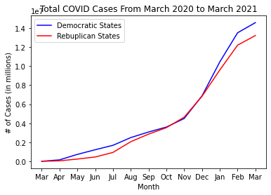

```python
# Create a matplotlib plot
fig1, axes1 = plt.subplots()

# Plotting our democrat and republican lines
axes1.plot(time_data['Date'], time_data['Dem_Cases'], c = 'Blue', label = 'Democratic States')
axes1.plot(time_data['Date'], time_data['Rep_Cases'], c = 'Red', label = 'Rebuplican States')

# Resetting and renaming the x-ticks so they are more clear.
axes1.set_xticks(range(0,13))
axes1.set_xticklabels(['Mar','Apr','May','Jun','Jul','Aug','Sep','Oct','Nov','Dec','Jan','Feb','Mar'])

# Naming the x-axis, y-axis, and plot title.
axes1.set_xlabel("Month")
axes1.set_ylabel("# of Cases (in millions)")
axes1.set_title('Total COVID Cases From March 2020 to March 2021')

# Adding a legend and displaying the plot.
axes1.legend()
fig1.show()
```

When we just look at total number of cases, we can see that Democratic states have more cases than Republican states for most time periods. But we thought we would see the opposite, right?

At this point, it is worth pointing out some of the potential drawbacks to the method we are choosing. In this plot, we are ignoring a substantial factor: population. By just plotting total cases, we are ignoring the differences in population that states have. For example, a state that has a high population would most likely have more COVID cases than one that has a relatively low population. This model also ignores population density, as groups of people in closer proximity to each other in areas like cities would spread a virus faster than groups in more spread out, rural areas. Remember how many cases New York had in the first few months of the pandemic compared to other states?

So instead of looking at total cases on their own, we can express this data as a percentage of total population to compensate. This way, we can compare states with different populations because we will be evaluating the percentage of total population that has been infected with COVID, not the total number of cases themselves. To do this, we add two more columns to our time data corresponding to these percentages.

```python
# Calculating the total population of Democratic and Republican States.
dem_population = main_data.loc[main_data['Election_Result'] == 'D']['Population'].sum()
rep_population = main_data.loc[main_data['Election_Result'] == 'R']['Population'].sum()

# Calculating the case percentages for each entry in the time_data table.
time_data['Dem_Case_Percentage'] = time_data['Dem_Cases'] / dem_population
time_data['Rep_Case_Percentage'] = time_data['Rep_Cases'] / rep_population
time_data
```

|  | Date | Dem_Cases | Rep_Cases | Dem_Case_Percentage | Rep_Case_Percentage |
| --- | --- | --- | --- | --- | --- |
| 0 | 03/01/2020 | 938 | 147 | 5.00477e-06 | 1.03997e-06 |
| 1 | 04/01/2020 | 149036 | 46525 | 0.000795194 | 0.000329147 |
| 2 | 05/01/2020 | 724204 | 232932 | 0.00386405 | 0.00164791 |
| 3 | 06/01/2020 | 1210949 | 449734 | 0.00646112 | 0.0031817 |
| 4 | 07/01/2020 | 1678268 | 928898 | 0.00895453 | 0.0065716 |
| 5 | 08/01/2020 | 2490154 | 2058556 | 0.0132864 | 0.0145635 |
| 6 | 09/01/2020 | 3078216 | 2853916 | 0.0164241 | 0.0201904 |
| 7 | 10/01/2020 | 3597083 | 3533755 | 0.0191925 | 0.025 |
| 8 | 11/01/2020 | 4495796 | 4633400 | 0.0239877 | 0.0327796 |
| 9 | 12/01/2020 | 6871422 | 6831737 | 0.036663 | 0.048332 |
| 10 | 01/01/2021 | 10446027 | 9595159 | 0.0557356 | 0.0678821 |
| 11 | 02/01/2021 | 13508930 | 12209927 | 0.072078 | 0.0863806 |
| 12 | 03/01/2021 | 14579541 | 13221019 | 0.0777903 | 0.0935337 |

We are making a few assumptions here that are worth pointing out. One is that we assume that the population for each state has not changed from month to month over the course of 2020. When it comes to our total number of COVID cases, we also assume that one case corresponds to one member of that state's population (i.e., no one got COVID twice, and each COVID case belongs to a resident of the state it was reported in).

Arguments can also be made that using 2020's election results to label states Republican or Democrat is not the best approach. For example, some states were highly contested up until the very end of the election, and simply labeling them D or R might not fully reflect the attitude of the state's population at large. Also, using 2020 election results means our political data is specific to that election's candidates and the public's attitudes to those candidates. Not to mention, the results of the 2020 election were most likely swayed by the Trump administration's handling of the pandemic itself.

A better approach might be to look at the number of voters in each state that are registered as Democrat or Republican and label each state as whichever of those groups is larger. This was the approach I initially wanted to take, but after realizing that some states do not require voters to align with a party when registering to vote, along with the fact that data of this kind was difficult to find, I went with the election approach knowing the potential sacrifices in accuracy and reliability I was making.

Making tradeoffs and recognizing the potential shortcomings of the data and analysis you are doing is a large part of data science. There are always assumptions to be made, and without all the data in the world our models can never be perfect. What matters is whether we acknowledge those assumptions and make them clear when communicating our results.

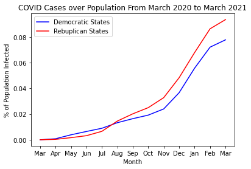

```python
# We perform the same process in making our line plot as above, only this time we use our percentage columns.
fig2, axes2 = plt.subplots()
axes2.plot(time_data['Date'], time_data['Dem_Case_Percentage'], c = 'Blue', label = 'Democratic States')
axes2.plot(time_data['Date'], time_data['Rep_Case_Percentage'], c = 'Red', label = 'Rebuplican States')
axes2.set_xticks(range(0,13))
axes2.set_xticklabels(['Mar','Apr','May','Jun','Jul','Aug','Sep','Oct','Nov','Dec','Jan','Feb','Mar'])
axes2.set_xlabel("Month")
axes2.set_ylabel("% of Population Infected")
axes2.set_title('COVID Cases over Population From March 2020 to March 2021')
axes2.legend()
fig2.show()
```

Now we have a plot that is more in line with what we expected to see. After expressing cases as a percentage of total population, we observe that after mid-July, Republican states start to overtake the Democratic states, despite Democratic states having more cases overall. However, this is a country-wide example, and it would benefit us to look closer at the state level to further examine this relationship. To do so, we will create a horizontal bar plot with states along the y-axis and their percent of population infected on the x-axis. We will also give Democratic states blue bars and Republican states red bars to easily differentiate the two political groups. Based on our hypothesis we expect to find the upper half of the graph to be populated mostly by Republican states.

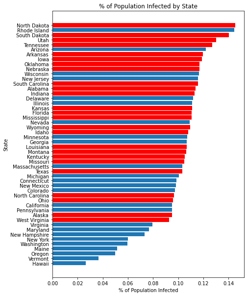

```python
# To have the bars in decreasing order, we must first sort the entries by the values in the Population_Infected column.
sorted_data = main_data.sort_values('Population_Infected')

# To turn the entries corresponding to Republican states red, we must reset the index and store the indices of Republican states in a list.
sorted_data = sorted_data.reset_index()
rep_index_list = sorted_data.index[sorted_data['Election_Result'] == 'R'].tolist()

# We need to stretch the plot so the y-axis is not squished and illegible, followed by plotting the data itself.
plt.figure(figsize=(7, 10))

plot = plt.barh(sorted_data['State'], sorted_data['Population_Infected'])

# We iterate through the index list we created earlier, turning the corresponding entries red.
for i in rep_index_list:
    plot[i].set_color('Red')

# Naming the x-axis, y-axis, and plot title.
plt.xlabel("% of Population Infected")
plt.ylabel("State")
plt.title('% of Population Infected by State')
plt.show()
# Of top 25, 9 Dem (36%), 16 Rep (64%)
```

Of the top 50% of states, 64% (16) are Republican states. While there are more Republican states than Democratic states in the top half of the graph, it's not exactly a sweep. While it is worth noting that the top of the graph is mostly occupied by Republican states, the correlation between COVID cases and political affiliation is not particularly strong, which makes sense given many of the assumptions we made about our data above.

There is one other aspect of COVID data we can explore though: vaccines. Since the COVID-19 vaccine has become more widely accessible, we could shift our perspective from COVID cases to COVID vaccinations by state. Since the total percentage of a population that is fully vaccinated is less susceptible to the assumptions we made earlier regarding the spread of a virus, we could see if there is a stronger correlation there by making the same plot as above, only this time exploring vaccination data.

While vaccination rates are much more susceptible to public perceptions, we are still making some assumption with this approach as well. For example, we are assuming that every state's population has equal access to receiving the COVID-19 vaccine, and that the vaccine is readily available to the general public in every state.

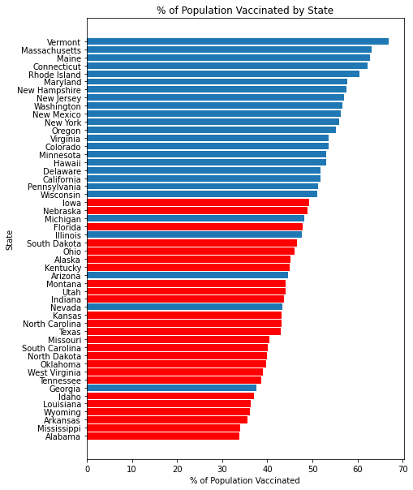

```python
# We perform the same steps as above using our vaccination data instead of our infection data.
sorted_data = main_data.sort_values('Population_Vaccinated')
sorted_data = sorted_data.reset_index()
rep_index_list = sorted_data.index[sorted_data['Election_Result'] == 'R'].tolist()

plt.figure(figsize=(7, 10))

plot = plt.barh(sorted_data['State'], sorted_data['Population_Vaccinated'])

for i in rep_index_list:
    plot[i].set_color('Red')

plt.xlabel("% of Population Vaccinated")
plt.ylabel("State")
plt.title('% of Population Vaccinated by State')
plt.show()
# Of top 25, 22 Dem (88%), 3 Rep (12%)
```

Wow. Now we see a much stronger separation of blue and red states. In the top 50% of the graph, 88% (22) are Democratic states, while only 12% (3) are Republican states. It is also worth pointing out that some of the Democratic states not occupying the upper half of the graph like Georgia and Nevada were considered battle ground states and were hotly contested in the 2020 election. It looks like the party divide is manifested much stronger in vaccination rates than in total COVID cases, and that makes sense when considering the types of data we are evaluating.

There are a ton of factors that impact virus spread, to the point where public perception might be considered one of the weakest (a virus does not care if you think it doesn't exist). On the other hand, one of the primary factors impacting vaccination rates is public perception and willingness, hence the frequent number of campaigns encouraging the public to get vaccinated (not only against COVID, but for other viruses too, like the flu).

# Machine Learning

Now we are going to shift our perspective a bit and focus on machine learning. Machine learning is a very complex topic, and we will not go into too much detail in this section. Basically, we want to know if COVID cases and vaccination rates are good predictors for whether a state is blue or red, and machine learning can help us answer this question.

On a very high level, machine learning is the process of using algorithms to "train" a computer to detect trends in data and to make predictions based on that training. We will be using supervised machine learning, where we know the expected outcomes and compare them with the predicted outcomes given to us by the computer. The more predictions the computer gets right, the higher the accuracy of our model is.

If you want to learn more about machine learning, I have provided some resources below.

```python
# We extract the columns we want to use in our machine learning algorithm.
ml_data = main_data[['Population_Vaccinated','Population_Infected','Election_Result']]

# Our predictors (Population_Vaccinated and Population_Infected).
X = ml_data.drop('Election_Result', axis = 1)

# Our expected output.
y = ml_data['Election_Result']
```

For this exercise we will be looking at two kinds of machine learning algorithms, k-NN or K Nearest Neighbors, and Decision Trees.

The k-NN algorithm assumes that similar data points are located "near" each other. The goal is to classify the points by calculating the distance from one point to a specified number of other points (our k).

Decision Trees more closely represent the decision making process that we make as humans. The computer makes choices of which branch to take, eventually resulting in an outcome.

These are very broad descriptions of these algorithms, and I have provided links below if you want to learn more about them.

Both algorithms, while different in their execution, are coded in roughly the same way. We create a Classifier object specific to the algorithm we want to use (we can also pass in arguments called hyperparameters to these classifiers to further optimize our algorithms, but for now we will use the default options). Then we will use a 10-fold cross validation to produce the accuracy of our models. The way this works is our data set is split into 10 different groups. One of these groups is assigned the role of the test group, while the rest are used as training groups. The training groups are used to train the algorithm, and the test group tests it to see how well it performs (hence the names test and train). This occurs 10 times, and after it is done, we can find the mean of the resulting scores to get a good estimate of the accuracy of our algorithms.

```python
# Create the classifier.
knc = KNeighborsClassifier()

# Run our cross validation.
scores_knc = cross_val_score(knc, X, y, cv=10)

# Print the results.
print('Accuracy: ', scores_knc.mean())
print('Standard Deviation: ', scores_knc.std())
print('Standard Error: ', (scores_knc.std())/(math.sqrt(10)))
```

```
Accuracy:  0.8600000000000001
Standard Deviation:  0.12806248474865697
Standard Error:  0.04049691346263317
```

```python
dtc = DecisionTreeClassifier()
scores_dtc = cross_val_score(dtc, X, y, cv=10)
print('Accuracy: ', scores_dtc.mean())
print('Standard Deviation: ', scores_dtc.std())
print('Standard Error: ', (scores_dtc.std())/(math.sqrt(10)))
```

```
Accuracy:  0.82
Standard Deviation:  0.16613247725836147
Standard Error:  0.052535702146254776
```

After running our algorithms, we can see that k-NN has a higher accuracy than our Decision Tree. An accuracy of 86% is fairly high, and with the inclusion of hyperparameters, we might be able to achieve an even higher level of accuracy.

Is this the most practical use of machine learning techniques? Not really. Our data set is not very big (only 50 entries for 50 states), and COVID data probably is not the most reliable predictor for future election results. Regardless, machine learning is utilized extensively in today's data-heavy industries, and it is worth discussing when delving into data science.

# Communication of insights attained

So, what have we learned?

When it comes to our hypothesis, we learned that there is a correlation between political affiliation and COVID cases, though maybe not quite as strong as we anticipated. Where we saw a stronger correlation was between political affiliation and vaccination rates. Moving forward, a good suggestion we could make from our conclusions is that more effort needs to be made in right-leaning states to encourage the public to get vaccinated, or that more work needs to be done to make getting a vaccine easier in larger states where the population is more widely dispersed.

When it comes to the data science pipeline, we walked through a real-life example of data science at work. We combined four, untidy data tables into two, neat datasets that we could work with, and we used different data visualization techniques to analyze our data and come to a conclusion. We also discussed some of the assumptions and drawbacks of our data, and how with more time and research we might be able to improve the accuracy of our models. Finally, we took a brief look at some machine learning techniques and how they can be applied to our data.

# Sources and External Resources

- Data Sources: Referenced Above
- Pandas User Guide: [https://pandas.pydata.org/docs/user_guide/index.html](http://url)
- NumPy Documentation: [https://numpy.org/doc/stable/](http://url)
- matplotlib Home Page: [https://matplotlib.org/](http://url)
- scikit-learn Home Page: [https://scikit-learn.org/stable/](http://url)
- Intro to Machine Learning: [https://www.ibm.com/cloud/learn/machine-learning](http://url)
- k-NN Algorithm: [https://www.analyticsvidhya.com/blog/2018/03/introduction-k-neighbours-algorithm-clustering/](http://url)
- Decision Tree Algorithm: [https://towardsdatascience.com/decision-trees-in-machine-learning-641b9c4e8052](http://url)
- k-fold Cross Validation: [https://machinelearningmastery.com/k-fold-cross-validation/](http://url)